# NYPD Historical Shooting Analysis

Anonymous

9/27/2021

The input dataset is a list of every shooting incident that occurred in NYC going back to 2006 through the end of the 2020. The datasource is available on the website https://catalog.data.gov/

It is manually extracted every quarter and reviewed by the Office of Management Analysis and Planning before being posted on the NYPD website. Each record represents a shooting incident in NYC and includes information about the event, the location and time of occurrence. In addition, information related to suspect and victim demographics is also included. This data can be used by the public to explore the nature of shooting/criminal activity.

[output not shown]

## Step One - Import the shooting project dataset in a reproducible manner

| Source the raw data from NYPD website and proceed with the analysis. |
| --- |

```r
library(tidyverse)
url_input <- "https://data.cityofnewyork.us/api/views/833y-fsy8/rows.csv?accessType=DOWNLOAD"

nypd_hist_shooting_data <- read_csv(url_input)
```

*Raw Data*

```r
nypd_hist_shooting_data
```

```
## # A tibble: 23,568 × 19
##    INCIDENT_KEY OCCUR_DATE OCCUR_TIME BORO          PRECINCT JURISDICTION_CODE
##           <dbl> <chr>      <time>     <chr>            <dbl>             <dbl>
##  1    201575314 08/23/2019 22:10      QUEENS             103                 0
##  2    205748546 11/27/2019 15:54      BRONX               40                 0
##  3    193118596 02/02/2019 19:40      MANHATTAN           23                 0
##  4    204192600 10/24/2019 00:52      STATEN ISLAND      121                 0
##  5    201483468 08/22/2019 18:03      BRONX               46                 0
##  6    198255460 06/07/2019 17:50      BROOKLYN            73                 0
##  7    194570529 03/11/2019 16:30      BROOKLYN            81                 0
##  8    203211777 10/03/2019 01:45      BROOKLYN            67                 0
##  9    193694863 02/17/2019 03:00      QUEENS             114                 2
## 10    199582060 07/10/2019 02:56      BROOKLYN            69                 0
## # … with 23,558 more rows, and 13 more variables: LOCATION_DESC <chr>,
## #   STATISTICAL_MURDER_FLAG <lgl>, PERP_AGE_GROUP <chr>, PERP_SEX <chr>,
## #   PERP_RACE <chr>, VIC_AGE_GROUP <chr>, VIC_SEX <chr>, VIC_RACE <chr>,
## #   X_COORD_CD <dbl>, Y_COORD_CD <dbl>, Latitude <dbl>, Longitude <dbl>,
## #   Lon_Lat <chr>
```

## Step 2 - Tidy and Transform Data

| remove records with NA/missing data, format date and discard unwanted columns like INCIDENT_KEY, PRECINCT, JURISDICTION_CODE, STATISTICAL_MURDER_FLAG, X_COORD_CD,Y_COORD_CD,Latitude,Longitude,Lon_Lat |
| --- |

```r
library(lubridate)
library(dplyr)

nypd_hist_shooting_data <- na.omit(nypd_hist_shooting_data) %>%
  mutate(OCCUR_DATE = mdy(OCCUR_DATE)) %>%
  select(-c(INCIDENT_KEY, PRECINCT, JURISDICTION_CODE, STATISTICAL_MURDER_FLAG, X_COORD_CD,Y_COORD_CD,Latitude,Longitude,Lon_Lat))
```

*Formatted Data*

```r
nypd_hist_shooting_data
```

```
## # A tibble: 6,843 × 10
##    OCCUR_DATE OCCUR_TIME BORO   LOCATION_DESC  PERP_AGE_GROUP PERP_SEX PERP_RACE
##    <date>     <time>     <chr>  <chr>          <chr>          <chr>    <chr>
##  1 2019-10-24 00:52      STATE… PVT HOUSE      25-44          M        BLACK
##  2 2019-02-17 03:00      QUEENS MULTI DWELL -… 18-24          M        BLACK
##  3 2019-08-21 23:34      STATE… GROCERY/BODEGA <18            M        WHITE HI…
##  4 2019-08-31 07:42      BRONX  GAS STATION    18-24          M        BLACK HI…
##  5 2019-02-24 23:20      BRONX  MULTI DWELL -… 18-24          M        BLACK
##  6 2019-07-03 00:04      QUEENS MULTI DWELL -… <18            M        WHITE
##  7 2019-06-29 05:48      BROOK… PVT HOUSE      18-24          M        BLACK
##  8 2019-11-10 14:03      BROOK… MULTI DWELL -… 25-44          M        BLACK
##  9 2019-07-28 14:35      MANHA… MULTI DWELL -… 25-44          M        WHITE HI…
## 10 2019-07-07 10:50      BROOK… PVT HOUSE      18-24          M        BLACK
## # … with 6,833 more rows, and 3 more variables: VIC_AGE_GROUP <chr>,
## #   VIC_SEX <chr>, VIC_RACE <chr>
```

*Summary*

| missing data is filtered out in previous step. |
| --- |

```r
summary(nypd_hist_shooting_data)
```

```
##    OCCUR_DATE          OCCUR_TIME           BORO           LOCATION_DESC
##  Min.   :2006-01-01   Length:6843       Length:6843        Length:6843
##  1st Qu.:2007-12-27   Class1:hms        Class :character   Class :character
##  Median :2010-03-21   Class2:difftime   Mode  :character   Mode  :character
##  Mean   :2011-04-04   Mode  :numeric
##  3rd Qu.:2013-10-08
##  Max.   :2020-12-27
##  PERP_AGE_GROUP       PERP_SEX          PERP_RACE         VIC_AGE_GROUP
##  Length:6843        Length:6843        Length:6843        Length:6843
##  Class :character   Class :character   Class :character   Class :character
##  Mode  :character   Mode  :character   Mode  :character   Mode  :character
##
##
##
##    VIC_SEX            VIC_RACE
##  Length:6843        Length:6843
##  Class :character   Class :character
##  Mode  :character   Mode  :character
##
##
##
```

## Step 3 - Visualization and Analysis

| Shootings by Boroughs |
| --- |

```r
library(ggplot2)

shootings_by_boroughs <- nypd_hist_shooting_data %>%
  count(BORO)
shootings_by_boroughs
```

```
## # A tibble: 5 × 2
##   BORO              n
##   <chr>         <int>
## 1 BRONX          1903
## 2 BROOKLYN       2709
## 3 MANHATTAN       983
## 4 QUEENS          992
## 5 STATEN ISLAND   256
```

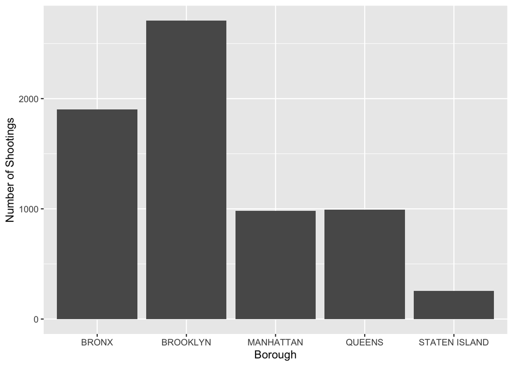

| Shootings by locations in a Borough |
| --- |

```r
ggplot(data = shootings_by_boroughs, mapping = aes(x = BORO, y= n)) +
  geom_bar(stat='identity') +
  labs(y = "Number of Shootings", x = "Borough")
```

```r
shootings_by_loc <- nypd_hist_shooting_data %>%
  count(BORO,LOCATION_DESC,sort = TRUE)
shootings_by_loc
```

```
## # A tibble: 120 × 3
##    BORO      LOCATION_DESC                 n
##    <chr>     <chr>                     <int>
##  1 BROOKLYN  MULTI DWELL - PUBLIC HOUS  1151
##  2 BRONX     MULTI DWELL - APT BUILD     708
##  3 BROOKLYN  MULTI DWELL - APT BUILD     705
##  4 BRONX     MULTI DWELL - PUBLIC HOUS   644
##  5 MANHATTAN MULTI DWELL - PUBLIC HOUS   504
##  6 QUEENS    MULTI DWELL - PUBLIC HOUS   285
##  7 MANHATTAN MULTI DWELL - APT BUILD     241
##  8 QUEENS    PVT HOUSE                   211
##  9 BROOKLYN  PVT HOUSE                   206
## 10 QUEENS    MULTI DWELL - APT BUILD     199
## # … with 110 more rows
```

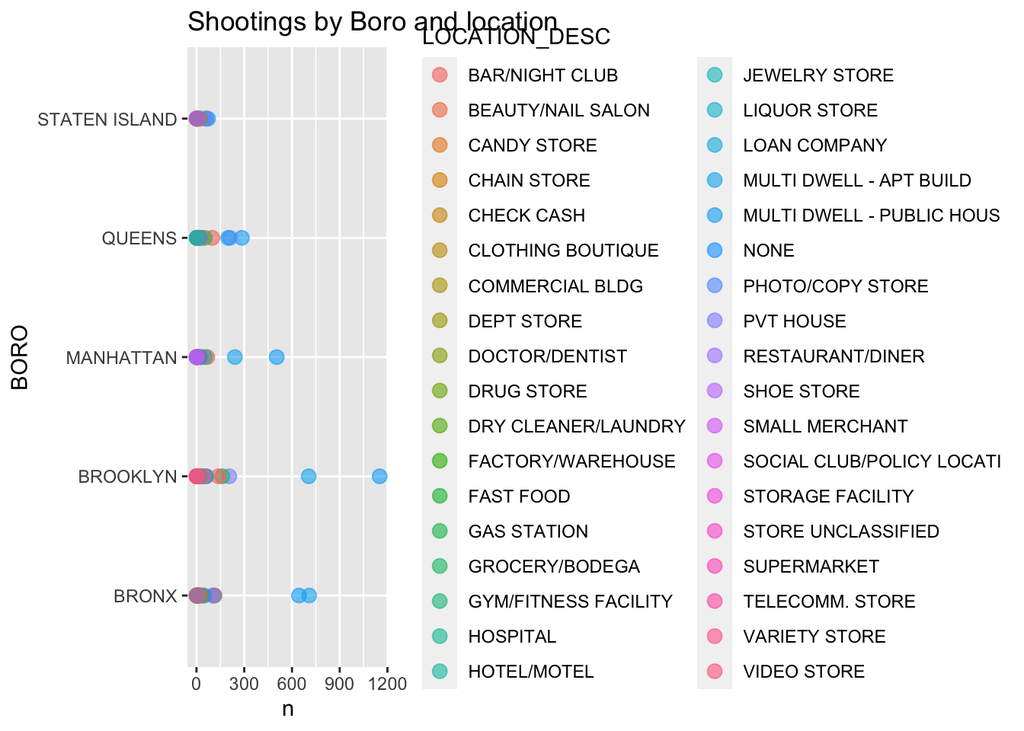

```r
ggplot(data = shootings_by_loc, mapping = aes(y = BORO, x= n, color=LOCATION_DESC)) +
  geom_point(size = 3,
             alpha = .6) +
  labs(title = "Shootings by Boro and location")
```

```r
### Perpetrator Sex
perp_sex <- nypd_hist_shooting_data %>%
  count(PERP_SEX,sort = TRUE)
perp_sex
```

```
## # A tibble: 3 × 2
##   PERP_SEX     n
##   <chr>    <int>
## 1 M         6072
## 2 U          595
## 3 F          176
```

```r
### Perpetrator Race
perp_race <- nypd_hist_shooting_data %>%
  count(PERP_RACE,sort = TRUE)
perp_race
```

```
## # A tibble: 7 × 2
##   PERP_RACE                          n
##   <chr>                          <int>
## 1 BLACK                           4633
## 2 WHITE HISPANIC                   802
## 3 UNKNOWN                          760
## 4 BLACK HISPANIC                   449
## 5 WHITE                            140
## 6 ASIAN / PACIFIC ISLANDER          58
## 7 AMERICAN INDIAN/ALASKAN NATIVE     1
```

| Shootings per year |
| --- |

```r
shooting_yr_in_boro <- nypd_hist_shooting_data %>%
  count(year = as.integer(year(OCCUR_DATE)), BORO,sort = TRUE)

shooting_yr_in_boro
```

```
## # A tibble: 75 × 3
##     year BORO         n
##    <int> <chr>    <int>
##  1  2006 BROOKLYN   415
##  2  2009 BROOKLYN   356
##  3  2008 BROOKLYN   329
##  4  2007 BROOKLYN   327
##  5  2006 BRONX      266
##  6  2010 BROOKLYN   232
##  7  2011 BROOKLYN   216
##  8  2008 BRONX      208
##  9  2007 BRONX      207
## 10  2009 BRONX      188
## # … with 65 more rows
```

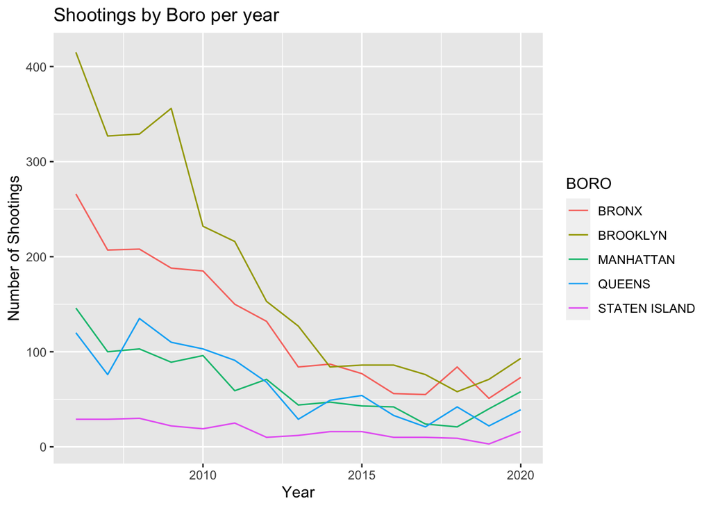

| Shootings at a given time |
| --- |

```r
ggplot(data = shooting_yr_in_boro, mapping = aes(x = year, y= n, color=BORO )) +
  geom_line() +
  labs(x ="Year", y = "Number of Shootings", title = "Shootings by Boro per year")
```

```r
shooting_time <- nypd_hist_shooting_data %>%
   count(BORO, time = OCCUR_TIME, sort=TRUE)

shooting_time
```

```
## # A tibble: 2,784 × 3
##    BORO     time       n
##    <chr>    <time> <int>
##  1 BRONX    01:58     18
##  2 BRONX    21:05     18
##  3 BROOKLYN 01:00     18
##  4 BROOKLYN 18:20     18
##  5 BRONX    01:05     17
##  6 BROOKLYN 03:30     17
##  7 BRONX    23:50     16
##  8 BROOKLYN 03:10     16
##  9 BRONX    21:35     15
## 10 BROOKLYN 23:55     15
## # … with 2,774 more rows
```

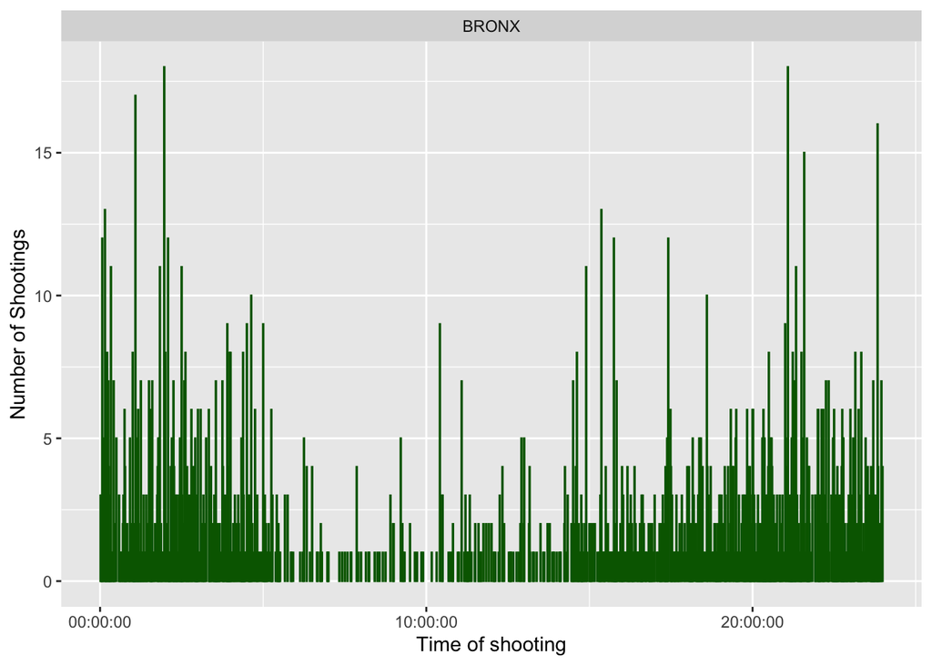

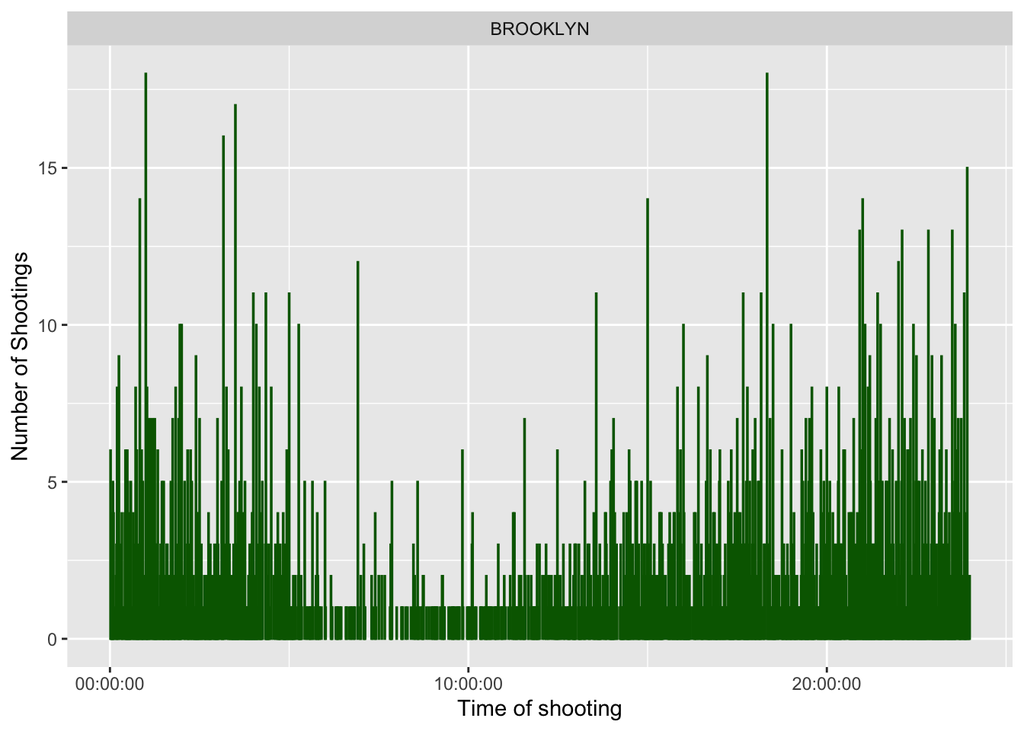

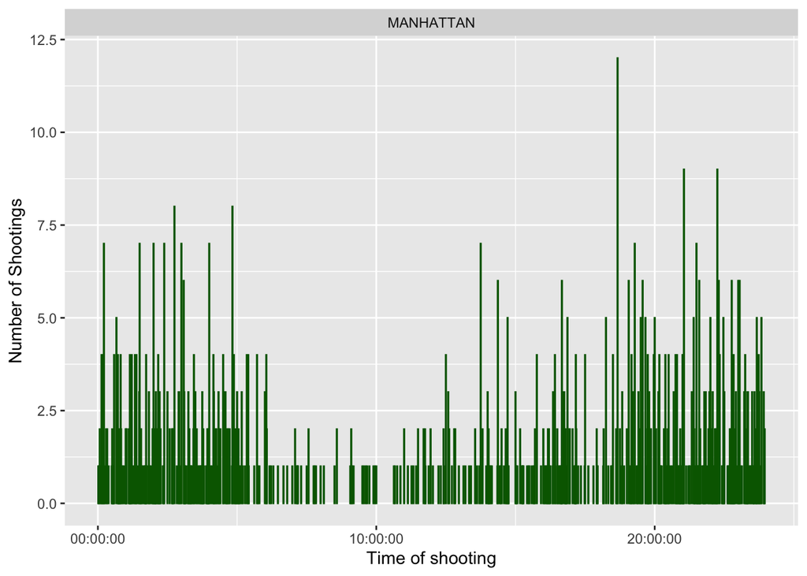

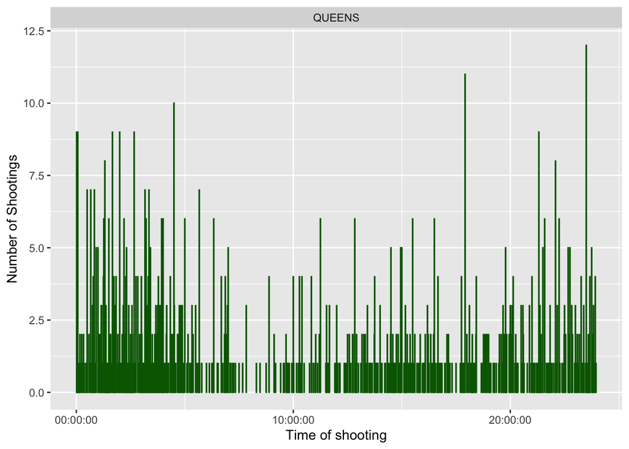

```
##
## $`STATEN ISLAND`
```

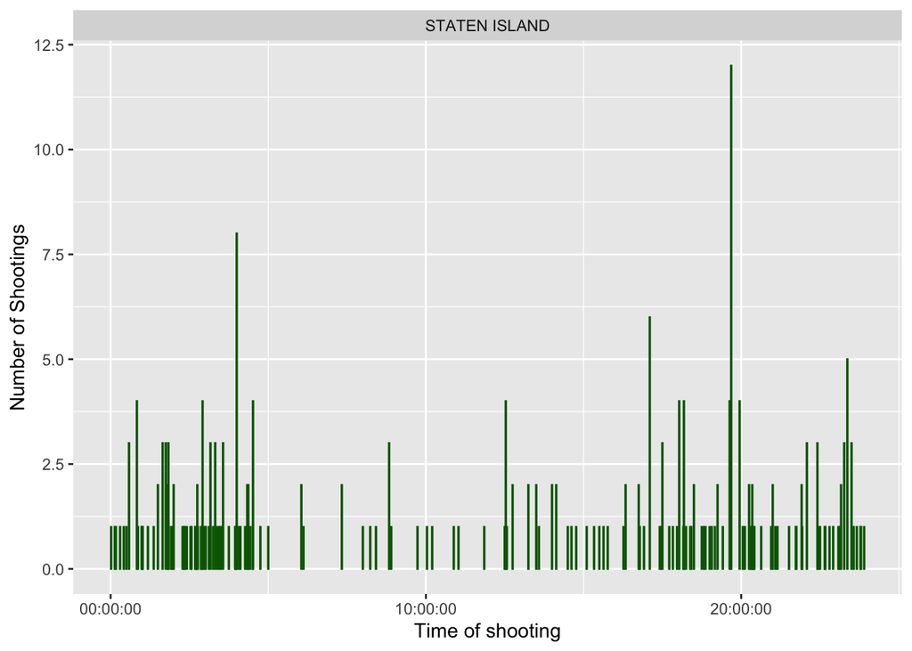

```r
shootings_per_boro <- lapply(split(shooting_time, shooting_time$BORO), function(x){
  ggplot(x) +
  geom_bar(stat='identity',aes(y=n , x=time), color="dark green") +
  labs(x ="Time of shooting", y = "Number of Shootings") +
  facet_wrap(vars(BORO))
})

shootings_per_boro
```

## Step 4 - Add Bias Identification

[output not shown]

Bias - Since Brooklyn has lowest income of people, my personal bias is that shooting rates are highest there. I have mitigated it by analysing the data by looking at Year on year shootings per Borough.